# SWCON425 Data Science and Visualization

# Plotly and Cufflinks

- Plotly is an open-source and charting library that provides the facility of interactive plotting. The library is available for several programming languages such as Python, R, MATLAB, and Arduino, among others.
- Plotly is a library that allows you to create interactive plots that you can use in dashboards or websites (you can save them as html files or static images).
- Cufflink is also a python library that connects plotly with pandas so that we can create charts directly on data frames. It basically acts as a plugin.
- Plotly charts are dynamic in nature, it allows us to hover over the values, zoom in zoom out of graphs, identifies outliers in the dataset.
- On the other hand, matplotlib and seaborn charts are static, we can’t zoom in or zoom-out, it does not provide detail of every value on the chart.
- The most important feature of plotly is that it allows us to build dynamic charts for the web directly from python which is not possible in the case of matplotlib.
- With plotly, we can also create animations and interactive graphs on geographical, scientific, statistical, and financial data.

## Installation

In order for this all to work, you will need to install plotly and cufflinks to call plots directly off of a pandas dataframe. Install the libraries ar your command line/terminal using:

```
!pip install plotly
!pip install cufflinks
!pip install chart_studio
```

```python
!pip install numpy==1.23.5
!pip install plotly==5.9.0
!pip install cufflinks==0.17.3
!pip install chart_studio==1.1.0
!pip install ipykernel
!pip install --upgrade nbformat
!pip install pandas==1.5.3
```

```python
import warnings
warnings.filterwarnings("ignore")

# We import all necessary modules in our python shell or jupyter notebook.
import pandas as pd
import numpy as np
import seaborn as sns
import matplotlib.pyplot as plt
%matplotlib inline

import plotly as py
import cufflinks as cf

# For enabling the offline mode for plotting locally in the jupyter notebook we write the below code.
from plotly.offline import init_notebook_mode, iplot
# for Notebooks
init_notebook_mode(connected=True)
# for offline use
cf.go_offline()
```

## Using Cufflinks and iplot()

## Sections

- line
- scatter
- bar
- boxplot
- area
- 3D surface
- 3D scatter plot
- spread
- histogram
- bubble
- heatmap

```python
print(py.__version__)
```

```
5.9.0
```

```python
df = pd.DataFrame()
help(df.iplot)
```

[output not shown]

[output cut: 403 more lines]

[output not shown]

## Embedding Graphs in HTML in Python

Plotly graphs can be embedded in any HTML page. This includes IPython notebooks, Wordpress sites, dashboards, blogs, and more.

For more on embedding Plotly graphs in HTML documents, see [plotly tutorial](https://plotly.com/python/interactive-html-export/).

```python
import chart_studio.tools as tls
tls.embed('https://plotly.com/~cufflinks/8/')
```

[interactive chart not shown]

```python
import chart_studio.tools as tls
tls.embed('https://plotly.com/~chris/1638')
```

[interactive chart not shown]

## Line

```python
df = pd.DataFrame(np.random.randn(100,3), columns = ['A', 'B', 'C'])
df.head()
```

|  | A | B | C |
| --- | --- | --- | --- |
| 0 | -0.199051 | -0.177795 | 0.588730 |
| 1 | -0.888165 | 0.328820 | 0.336823 |
| 2 | 0.120418 | 0.198465 | 0.414805 |
| 3 | -0.297889 | -0.329752 | 0.380392 |
| 4 | 0.382442 | -1.518502 | 0.547784 |

```python
df.shape
```

```
(100, 3)
```

```python
df.iplot()
```

[interactive chart not shown]

```python
df = pd.DataFrame(np.random.randn(100,3), columns = ['A', 'B', 'C'])
df.head()
df['A'] = df['A'].cumsum()
df['B'] = df['B'].cumsum()
df['C'] = df['C'].cumsum()
```

```python
df.iplot()
```

[interactive chart not shown]

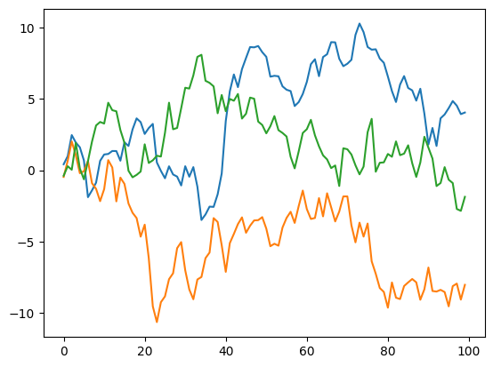

```python
plt.plot(df)
```

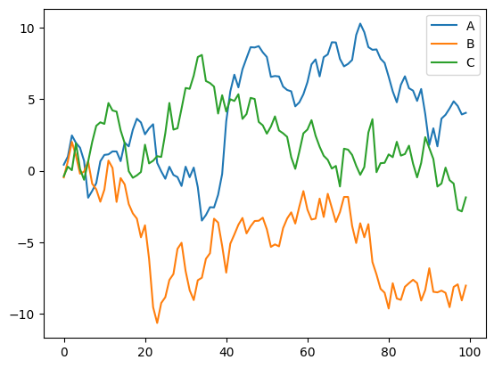

```python
df.plot()
```

[back to top]

## Scatter

```python
df.iplot(x="A", y="B", mode='markers', size=5)
```

[interactive chart not shown]

[back to top]

## Bar

```python
titanic = sns.load_dataset('titanic')
titanic.head()
```

|  | survived | pclass | sex | age | sibsp | parch | fare | embarked | class | who | adult_male | deck | embark_town | alive | alone |
| --- | --- | --- | --- | --- | --- | --- | --- | --- | --- | --- | --- | --- | --- | --- | --- |
| 0 | 0 | 3 | male | 22.0 | 1 | 0 | 7.2500 | S | Third | man | True | NaN | Southampton | no | False |
| 1 | 1 | 1 | female | 38.0 | 1 | 0 | 71.2833 | C | First | woman | False | C | Cherbourg | yes | False |
| 2 | 1 | 3 | female | 26.0 | 0 | 0 | 7.9250 | S | Third | woman | False | NaN | Southampton | yes | True |
| 3 | 1 | 1 | female | 35.0 | 1 | 0 | 53.1000 | S | First | woman | False | C | Southampton | yes | False |
| 4 | 0 | 3 | male | 35.0 | 0 | 0 | 8.0500 | S | Third | man | True | NaN | Southampton | no | True |

```python
titanic.iplot(kind='bar', x='sex', y='survived', title="Survived", xTitle="Sex", yTitle="#Survived")
```

[interactive chart not shown]

```python
titanic['sex'].value_counts()
```

```
male      577
female    314
Name: sex, dtype: int64
```

```python
df.iplot(kind='barh', barmode='stack', bargap=0.5)
```

[interactive chart not shown]

```python
# get theme
cf.getThemes()
```

```
['ggplot', 'pearl', 'solar', 'space', 'white', 'polar', 'henanigans']
```

```python
# set different theme
cf.set_config_file(theme='henanigans')
df.iplot(kind='bar', barmode='stack', bargap=0.5)
```

[interactive chart not shown]

[back to top]

## Boxplot

```python
df.iplot(kind='box')
```

[interactive chart not shown]

[back to top]

## Area

```python
df.iplot(kind='area', fill=True)
```

[interactive chart not shown]

[back to top]

## 3D surface

```python
df3 = pd.DataFrame({'X':[10,20,30,20,10],'Y':[10,20,30,20,10],'Z':[10,20,30,20,10]})
df3.head()
```

|  | X | Y | Z |
| --- | --- | --- | --- |
| 0 | 10 | 10 | 10 |
| 1 | 20 | 20 | 20 |
| 2 | 30 | 30 | 30 |
| 3 | 20 | 20 | 20 |
| 4 | 10 | 10 | 10 |

```python
df3.iplot(kind='surface')
```

[interactive chart not shown]

```python
# change color scale
df3.iplot(kind='surface', colorscale='rdylbu')
```

[interactive chart not shown]

```python
help(cf.datagen)
```

[output not shown]

[output cut: 192 more lines]

[output not shown]

```python
cf.datagen.sinwave(10, 0.25).iplot(kind='surface')
```

[interactive chart not shown]

## 3D scatter plot

```python
cf.datagen.scatter3d(2, 150, mode='stocks').iplot(kind='scatter3d', x='x', y='y', z='z')
```

[interactive chart not shown]

[back to top]

## Spread

```python
# df[['A'], ['B']].iplot(kind='spread')
df[['A', 'B']].iplot(kind='spread')
```

[interactive chart not shown]

[back to top]

## Histogram

```python
df.iplot(kind='hist', bins=25, barmode='group', bargap=0.5)
```

[interactive chart not shown]

[back to top]

## Bubble

```python
cf.datagen.bubble3d(5,4, mode='stocks').iplot(kind='bubble3d', x='x', y='y', z='z', size='size')
```

[interactive chart not shown]

[back to top]

## Heatmap

```python
cf.datagen.heatmap(20, 20).iplot(kind='heatmap', colorscale='spectral', title='Cufflinks')
```

[interactive chart not shown]

[back to top]

# Chart Visualization

## Chart Sections

- Line charts
- Bar charts
- Area charts
- Plot Styling
- Layout

## Line Charts

```python
df = cf.datagen.lines()
df.head()
```

|  | EJM.FO | NHI.EQ | GXA.UC | UWA.FD | LBW.VU |
| --- | --- | --- | --- | --- | --- |
| 2015-01-01 | 0.257656 | 1.115393 | 0.128626 | -0.173209 | 2.060600 |
| 2015-01-02 | -0.909590 | 0.151738 | -0.652102 | -0.188754 | 2.466593 |
| 2015-01-03 | -0.640404 | 1.009996 | -1.737407 | 1.270847 | 1.260700 |
| 2015-01-04 | -0.824190 | 0.984260 | -3.151694 | -0.680223 | 1.466241 |
| 2015-01-05 | -2.886908 | 0.874833 | -2.952853 | 0.039610 | 2.400730 |

```python
df.iplot(kind='line')
```

[interactive chart not shown]

[back to top]

## Bar Charts

```python
df = pd.DataFrame(np.random.rand(10, 4), columns=['A', 'B', 'C', 'D'])
df.head()
```

|  | A | B | C | D |
| --- | --- | --- | --- | --- |
| 0 | 0.570062 | 0.386772 | 0.297693 | 0.266551 |
| 1 | 0.022649 | 0.209386 | 0.157867 | 0.918471 |
| 2 | 0.015242 | 0.646925 | 0.508326 | 0.602004 |
| 3 | 0.962543 | 0.762459 | 0.902361 | 0.006719 |
| 4 | 0.514934 | 0.640343 | 0.989504 | 0.501955 |

```python
df.iplot(kind='bar', barmode='group')
```

[interactive chart not shown]

```python
df.iplot(kind='bar', barmode='stack')
```

[interactive chart not shown]

```python
df['A'].iplot(kind='bar')
```

[interactive chart not shown]

```python
df.iplot(kind='barh', barmode='stack')
```

[interactive chart not shown]

```python
df['A'].iplot(kind='barh')
```

[interactive chart not shown]

[back to top]

## Area Charts

```python
df.iplot(kind='area')
```

[interactive chart not shown]

```python
df.iplot(kind='area', fill=True)
```

[interactive chart not shown]

```python
df.iplot(fill=True)
```

[interactive chart not shown]

[back to top]

## Plot Styling

```python
themes = cf.getThemes()
themes
```

```
['ggplot', 'pearl', 'solar', 'space', 'white', 'polar', 'henanigans']
```

```python
data = pd.Series(range(10))
for theme in themes:
    data.iplot(kind='bar', theme=theme, title=theme)
```

[interactive chart not shown]

[back to top]

## Layout

```python
layout = {
    'font': {
        'family': 'consolas',
        'size': 20,
        'color': 'red'
    }
}
layout['title'] = "Title"

data.iplot(kind='bar', layout=layout)
```

[interactive chart not shown]

[back to top]

# Plotly Express

[Plotly_express API documentation](https://plotly.com/python-api-reference/plotly.express.html)  
[Introducing Plotly Express](https://medium.com/plotly/introducing-plotly-express-808df010143d)

```python
!pip install plotly_express
```

```python
import plotly.express as px
import pandas as pd
```

## Scatter Charts

```python
iris = px.data.iris()
iris.head()
```

|  | sepal_length | sepal_width | petal_length | petal_width | species | species_id |
| --- | --- | --- | --- | --- | --- | --- |
| 0 | 5.1 | 3.5 | 1.4 | 0.2 | setosa | 1 |
| 1 | 4.9 | 3.0 | 1.4 | 0.2 | setosa | 1 |
| 2 | 4.7 | 3.2 | 1.3 | 0.2 | setosa | 1 |
| 3 | 4.6 | 3.1 | 1.5 | 0.2 | setosa | 1 |
| 4 | 5.0 | 3.6 | 1.4 | 0.2 | setosa | 1 |

```python
fig = px.scatter(iris, x="sepal_width", y="sepal_length")
fig.show()
```

[interactive chart not shown]

## Parallel Coordinates Charts

```python
fig = px.parallel_coordinates(iris,
                              color="species_id",
                              labels={
                                  "species_id": "Species",
                                  "sepal_width": "Sepal Width",
                                  "sepal_length": "Sepal Length",
                                  "petal_width": "Petal Width",
                                  "petal_length": "Petal Length",},
                              color_continuous_scale=px.colors.diverging.Tealrose,
                              color_continuous_midpoint=2)
fig.show()
```

[interactive chart not shown]

## Parallel Categories Charts

```python
tips = px.data.tips()
tips.head()
```

|  | total_bill | tip | sex | smoker | day | time | size |
| --- | --- | --- | --- | --- | --- | --- | --- |
| 0 | 16.99 | 1.01 | Female | No | Sun | Dinner | 2 |
| 1 | 10.34 | 1.66 | Male | No | Sun | Dinner | 3 |
| 2 | 21.01 | 3.50 | Male | No | Sun | Dinner | 3 |
| 3 | 23.68 | 3.31 | Male | No | Sun | Dinner | 2 |
| 4 | 24.59 | 3.61 | Female | No | Sun | Dinner | 4 |

```python
fig = px.parallel_categories(tips, color="size", color_continuous_scale=px.colors.sequential.Inferno)
fig.show()
```

[interactive chart not shown]